# 2. Basics of Python for Data Science

These are very first set of syntax in Python programming. These are concepts that we need to know and use in a repeatable manner in future work.

The goal of this class is to begin writing syntactically correct snippets of code as a precursor to doing data analysis.

# 2.1 Simplest of syntaxes

- The 'print' syntax allows you to print textual output of your programs. Here are a few examples of how the print statement works.
- This is pretty much axiometric- this is how it is defined in the programming syntax.
- A few interesting output formating of print is provided below, for you to repurpose and reuse

```python
# Prints like a computer
course_num= 'BAUN493'
class_size= 13
pct_A= .9
avg_score= 96.58154

#Print a charcater string
print('Course Number:', course_num)
print('Class Size:', class_size)
print('Average Class Score:', avg_score)
print('% Scored a A or better:',pct_A)
```

```
Course Number: BAUN493
Class Size: 13
Average Class Score: 96.58154
% Scored a A or better: 0.9
```

## 2.1.1. Formated Print Output

Gives you lot more flexibility to output results almost as in the English language.

The following are a few examples that you are instructive and you should try and use in your work

```python
# Prints like English
course_num= 'BAUN493'
class_size= 13
pct_A= .9
avg_score= 96.58154

print('Course Number {0:s} has a class size of {1:d} with {2:.2%} \
scoring over an A with an Average Raw Score of {3:.2f}'.\
format(course_num, class_size, pct_A, avg_score))
```

```
Course Number BAUN493 has a class size of 13 with 90.00% scoring over an A with an Average Raw Score of 96.58
```

Observations:

1. Entire sentence in ''
2. Line continuation is managed through

   \
3. Variables are indexed by 0..3
4. Formats are specific to the variable types and their usage

These are commonly used output formating in the course. For more illustrations, you may look [here](https://www.geeksforgeeks.org/python-format-function/)

# 2.2. Variables and Data Types

- Variables are containers for storing data values.
- The Python interpretor allocates computer memory for each defined variables

## 2.2.1. Variable Declaration

- In Python, a variable is created the moment you first assign a value to it.
- When we run the code `x = 3`, the value `3` is saved in the computer memory. The computer memory has large number of storage locations, and `3` is saved to one particular location.
- The storage location to which we saved `3` has a unique identifier, and we can use it to access `3`. The identifier is named `x`, and we named it that way when we ran the code `x = 3`

```python
x=3
```

```python
y='Hello World'
```

```python
# Syntactically correct way of defining 2 variables in one line of code. Not really a great idea
x=3;y='Hello World'
```

## 2.2.2. Data Types in Python

- Booleans are either True or False.
- Numbers can be integers (1 and 2), floats (1.1 and 1.2), fractions (1/2 and 2/3), or even complex numbers.
- Strings are sequences of Unicode characters, e.g. an html document.
- Lists are ordered sequences of values.
- Tuples are ordered, immutable sequences of values.
- Sets are unordered bags of values.
- Dictionaries are unordered bags of key-value pairs.

#### 2.2.2.1. Boolean

- The boolean data type is either `True` or `False`. In Python, boolean variables are defined by the `True` and `False` keywords.
- The output `<class 'bool'>` indicates the variable is a boolean data type.
- Note the keywords `True` and `False` must have an Upper Case first letter. Using a lowercase true returns an `error`.

```python
x = True # True and False are case senstitve
y = False
```

```python
print(type(x))
```

[output not shown]

```python
x= true
```

```
---------------------------------------------------------------------------
NameError                                 Traceback (most recent call last)
<ipython-input-59-9b2be4a47841> in <module>()
----> 1 x= true

NameError: name 'true' is not defined
```

#### 2.2.2.2. Number

There are three numeric types in Python:

```
int
float
complex
```

Variables of numeric types are created when you assign a value to them

```python
x=1 ; y=2.5
```

```python
print(type(x))
```

```
<class 'int'>
```

```python
print(type(y))
```

```
<class 'float'>
```

#### 2.2.2.3. Strings

```python
myString = "This is a test!!"
```

- We can access a specific element using an integer index which counts from the front of the string
- Note: Index starts at **ZERO**!

```python
print(myString[0]) #produces 'T'
print(myString[1]) #produces 'h'
print(myString[2]) #produces 'i'
print(myString[3]) #produces 's'
print(myString[4]) #Guess what!!
```

```
T
h
i
s
```

- Included blank characters `' '` are considered as a character as well
- The len() function can be used to find the length of a sequence
- Remember, the last element is the length minus 1, because counting starts at zero!

```python
print(len(myString))
```

```
16
```

```python
myString[15]
```

```
'!'
```

Knowing a length of a string can be very handy when you are trying to manipulate it in a `loop`

##### 2.2.2.3.1. Indexing Backwards

```python
print(myString)
print('================')
print('Last character: ', myString[-1])
print('2nd last character: ',myString[-2])
print('3rd last character: ',myString[-3])
print('4th from last: ',myString[-4])
print('First character: ', myString[-len(myString)])
```

```
This is a test!!
================
Last character:  !
2nd last character:  !
3rd last character:  t
4th from last:  s
First character:  T
```

##### 2.2.2.3.2. Grabbing Slices from a Sequence

- The slice operator will clip out part of a sequence.
- It looks a lot like the bracket operator, but with a colon that separates the “start” and “end” points.
- SEQUENCE_VAR [ START : END : STEP]
- START: start index
- END: Up to index but not including END
- STEP: Characters to jump after retrieving each character in the slice

```python
print('1. Variable myString: ', myString, x)
```

```
1. Variable myString:  This is a test!! True
```

```python
print('1. Variable myString: ', myString)
print('2. Starts at 0 and prints until index 2: ',myString[0:3])
print('3. Starts at 3 and prints until index 8: ',myString[3:9])
print('4. Starts at 3 and prints until index 8, skipping every 2nd caharacter: ',myString[3:9:2])
print('5. Leaving start blank, assumes 0: ',myString[:3] )
print('6. Leaving assumes you want until the end of the string: ', myString[3:])
print('7. Leaving both ends blank reproduces the string: ', myString [ : ])
print('8. PALINDROME- reverses the string: ', myString[: : -1])
```

```
1. Variable myString:  This is a test!!
2. Starts at 0 and prints until index 2:  Thi
3. Starts at 3 and prints until index 8:  s is a
4. Starts at 3 and prints until index 8, skipping every 2nd caharacter:  si
5. Leaving start blank, assumes 0:  Thi
6. Leaving assumes you want until the end of the string:  s is a test!!
7. Leaving both ends blank reproduces the string:  This is a test!!
8. PALINDROME- reverses the string:  !!tset a si sihT
```

#### 2.2.2.4 Tuple

- Tuples are sequences of objects, just like lists.
- Tuples are immutable i.e. you cannot modify tuples.
  - Hold heterogenous data
  - Since tuples are immutable, iterating through a tuple is faster than a list
  - If data doesn't change, implementing as tuple guarantees it remains write-protected.
  - Generalizing this, a tuple can be used to group any number of items into a single compound value. Syntactically, a tuple is a comma-separated sequence of values.

```python
T1 = (5,4,2,6,7)
print(T1)
print(type(T1))

T2= 5,4,2,6,7
print(T2)
print(type(T2))
x1 = (5)
print(x1)
print(type(x1))

T2= (5,) #  Tuple with only single element is defined by specifying item with comma within an optional pair of parentheses.

print(T2)
print(type(T2))
```

```
(5, 4, 2, 6, 7)
<class 'tuple'>
(5, 4, 2, 6, 7)
<class 'tuple'>
5
<class 'int'>
(5,)
<class 'tuple'>
```

Tuples are **IMMUTABLE**

```python
T1= (5,4,2,6,7)
print(T1)
T1[2] = 4
```

```
(5, 4, 2, 6, 7)
```

```
---------------------------------------------------------------------------
TypeError                                 Traceback (most recent call last)
<ipython-input-87-9bdf4fec2945> in <module>()
      1 T1= (5,4,2,6,7)
      2 print(T1)
----> 3 T1[2] = 4

TypeError: 'tuple' object does not support item assignment
```

```python
T1 = [(2,3),(4,5),('b',7),(8,9)]
print(type(T1))
for t in T1:
    print (t)
    print(type(t))
```

```
<class 'list'>
(2, 3)
<class 'tuple'>
(4, 5)
<class 'tuple'>
('b', 7)
<class 'tuple'>
(8, 9)
<class 'tuple'>
```

- Defining a tuple with heterogenous data types
- Assigning tuple values to different variables

```python
T1= (2,'b',3.2,10,(4,2))
print(T1)
i1,i2,i3,i4,i5 = T1
print(i1,i2,i3,i4,i5)
print(i5)
print(type(i5))
```

```
(2, 'b', 3.2, 10, (4, 2))
2 b 3.2 10 (4, 2)
(4, 2)
<class 'tuple'>
```

*Note:* We shall now take a short detour into python control structures and loops before going any further with data types as the Python control structures are essential in manipulating and observing these

# 2.3 Control Structures

- Two important control structures:
  - Iteration
  - Selection.
- Analyst can choose the statement that is most useful for the given circumstance.

## 2.3.1. Conditional Statements

[figure not shown]

```python
from IPython.display import Image
Image("https://media.geeksforgeeks.org/wp-content/uploads/20191122131748/Python-logical-and-operator2.jpg")
```

```python
a = 3
if a <= 5:
  print("Condition is True")
```

```
Condition is True
```

```python
a = 0
print ("Another Statement")
if a == 0:
    print("I am in IF Block")
else:
    print("I am in ELSE Block")
```

```
Another Statement
I am in IF Block
```

```python
var = 4900
if (var < 200 and var >= 50):
    print ("Expression value is less than 200 & greater than 50")
    if var == 150:
        print ("Which is 150")
    elif var == 100:
        print ("Which is 100")
    elif var == 50:
        print ("Which is 50")
elif var < 50:
    print ("Expression value is less than 50")
else:
    print ("Could not find true expression")
```

```
Could not find true expression
```

Note:

- `==`: For testing equavalency
- `<` : Less than
- `>=`: Greater than or equal to

## 2.3.2. Iteration

### 2.3.2.1. For Loops

[figure not shown]

```python
from IPython.display import Image
Image("https://media.geeksforgeeks.org/wp-content/uploads/20191101172216/for-loop-python.jpg")
```

```python
n = 12
for i in range(2,n):
    print(i)
```

```
2
3
4
5
6
7
8
9
10
11
```

The range() function returns a sequence of numbers, starting from 0 by default, and increments by 1 (by default), and stops before a specified number.

```
 range(start, stop, step)
```

- start *Optional.* An integer number specifying at which position to start. Default is 0
- stop *Required.* An integer number specifying at which position to stop (not included).
- step *Optional.* An integer number specifying the incrementation. Default is 1

### 2.3.2.2. While Loops

[figure not shown]

```python
from IPython.display import Image
Image("https://media.geeksforgeeks.org/wp-content/uploads/20191101170515/while-loop.jpg")
```

```python
n = 5
i = 1
while(i <= n):
    print(i)
    i = i + 1
```

```
1
2
3
4
5
```

### 2.3.2.3. Application: Easy Traversal

```python
myString
```

```
'This is a test!!'
```

```python
for myVar in myString:
  # print(myVar)
  if myVar == 'T':
    print ("I found a T!")
```

```
I found a T!
```

```python
for letter in 'Django':    # First Example
    if letter == 'D':
        continue
    print ('Current Letter:', letter)
```

```
Current Letter: j
Current Letter: a
Current Letter: n
Current Letter: g
Current Letter: o
```

```python
for letter in 'Python':     # First Example
    if letter == 'h':
        break
    print ('Current Letter :', letter)
print ('Out of For')
```

```
Current Letter : P
Current Letter : y
Current Letter : t
Out of For
```

# 2.4 Python List

## 2.4.1. Basic Syntax

**List:**

- A list is represented with [] (square brackets) and is created by providing values separated by “,”.
- A list is a data structure that holds an ordered collection of items i.e. you can store a sequence of items in a list.
- The list of items should be enclosed in square brackets so that Python understands that you are specifying a list.
- Once you have created a list, you can add, remove or search for items in the list.
- Since we can add and remove items, we say that a list is a mutable data type i.e. this type can be altered.

```python
x = [1,2,3]
print(type(x))
```

```
<class 'list'>
```

```python
y = [10.5,23.45,34.56,45.78]
print(y)
```

```
[10.5, 23.45, 34.56, 45.78]
```

```python
z = ['q','r','s','t']
print (z)
```

```
['q', 'r', 's', 't']
```

1. List allow duplicates of values.

```python
x = [10,25,10,38,25]
print(x)
```

```
[10, 25, 10, 38, 25]
```

1. A list contains ordered set of elements , hence can be accessed by using index which starts from 0.

```python
x = [10,25,12,38,24]
print(x[0])
print(x[3])
#print (x[5])
```

```
10
38
```

1. Index values greater than range then error is generated.
2. Reverse index is also possible just like strings.

```python
x = [10,25,10,38,25]
print(x[-1])
```

```
25
```

```python
len(x)
```

```
5
```

1. Empty list can be created in two different ways.

```python
a = []
print(a)

b=list()
print(b)
```

```
[]
[]
```

1. Elements in list can be updated since list is mutable.

```python
x = [10,25,10,38,25]
print(x[1])
x[1] = 5
print(x[1])
print(x)
```

```
25
5
[10, 5, 10, 38, 25]
```

## 2.4.2. List Assignment and Equivalence

List assignment is used to assign all the elements of list to another list.

- Below, memory is allocated for both objects separately

```python
a = [2,4,6]
c = list(a)
print(c)
c[0] = 10
print(c)
print(a)
```

```
[2, 4, 6]
[10, 4, 6]
[2, 4, 6]
```

- List are assigned through memory location
- Changing one list effects the other, as the memory locations are the same

```python
a = [2,4,6]
b = a
print(b)
b[1] = 12
print(a ,b)
```

```
[2, 4, 6]
[2, 12, 6] [2, 12, 6]
```

## 2.4.3. List Comparison and slicing

1. List elements or list as whole also can be compared.

```python
a = [2,4,6]
b = [3,2,5]
print (a[1]==b[1])
print (a[0]==b[1])
print (a==b)
```

```
False
True
False
```

1. List slicing is same as string slicing .

```python
a = [0,1,2,3,4,5,6,7,8,9,10]
print(a[1:4])
print(a[:6])
print(a[3:])
print(a[2:8:2])
print(a[2:10:2])
```

```
[1, 2, 3]
[0, 1, 2, 3, 4, 5]
[3, 4, 5, 6, 7, 8, 9, 10]
[2, 4, 6]
[2, 4, 6, 8]
```

## 2.4.4. Nested list

List can have list itself as its elements.

```python
x = [[2,4,6] ,[3,2,5]]
print (x)
for i in x:
    print(i)
    for j in i :
        print(j)

#### Print individual elements for following list.
y = [[[2],[2,3,4],[6,5]] ,[[3],[2,5]]]
```

```
[[2, 4, 6], [3, 2, 5]]
[2, 4, 6]
2
4
6
[3, 2, 5]
3
2
5
```

## 2.4.5. List comprehension

- List comprehensions are used for creating new list from another iterables.
- As list comprehension returns list, they consists of brackets containing the expression which needs to be executed for each element along with the for loop to iterate over each element.
- Basic syntax:
- new_list = [expression for_loop_one_or_more condtions]

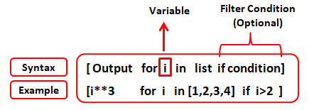

```python
from IPython.display import Image
Image("https://4.bp.blogspot.com/-uRPZqKbIGwQ/XRtgWhC6qqI/AAAAAAAAH0w/--oGnwKsnpo00GwQgH2gV3RPwHwK8uONgCLcBGAs/s1600/comprehension.PNG")
```

```python
numbers = [1,2,3,4]
squares=[]
for i in numbers:
    squares.append(i**2)
```

```python
print(squares)
```

```
[1, 4, 9, 16]
```

Above loop in the form of a list comprehension

```python
squares2 = [i**2 for i in numbers]
print(squares2)
```

```
[1, 4, 9, 16]
```

Finding common numbers in 2 list

```python
# Find common numbers from two list using for loop.

list_a = [1, 2, 3, 4]
list_b = [2, 3, 4, 5]

common_num = [a for a in list_a for b in list_b if a == b]

print(common_num) # Output: [2, 3, 4]
```

```
[2, 3, 4]
```

Creating a nested list

```python
list_a = [1, 2, 3]
list_b = [2, 7]

different_num = [(a, b) for a in list_a for b in list_b if a != b]

print(different_num) # Output: [(1, 2), (1, 7), (2, 7), (3, 2), (3, 7)]
```

```
[(1, 2), (1, 7), (2, 7), (3, 2), (3, 7)]
```

# 2.5. Python Dictionaries

- Pairs of keys and values are specified in a dictionary by using the notation

  ```
   d = {key1 : value1, key2 : value2 }
  ```

- Notice that the key-value pairs are separated by a colon and the pairs are separated themselves by commas and all this is enclosed in a pair of curly braces.
- Remember that key-value pairs in a dictionary are not ordered in any manner. If you want a particular order, then you will have to sort them yourself before using it.
- The dictionaries that we will be using are instances/objects of the dict class.

## 2.5.1 Dictionary Creation

Variable assigned with empty curly braces will have data type **"dict"**. But variable assigned with a single value will have datatype **"set"**. Refer variable **d1** and **d3** respectively.

```python
d1 = {}
print (d1)
print(type(d1))
```

```
{}
<class 'dict'>
```

```python
d2 = dict()
print (d2)
```

```
{}
```

```python
d3 = {3}
print (d3)
print (type(d3))
```

```
{3}
<class 'set'>
```

```python
d1 = {'a' : 3 ,'b':4}
print (d1)
print (type(d1))
```

```
{'a': 3, 'b': 4}
<class 'dict'>
```

```python
d1['b']
```

```
4
```

Creating Dictionary using **list of tuples**.

```python
d1 = dict([('a',3), ('b',5)])
print (d1)
```

```
{'a': 3, 'b': 5}
```

Creating Dictionary using **list of lists.**

```python
d2= dict([['a',3], ['b',5]])
print (d2)
```

```
{'a': 3, 'b': 5}
```

```python
d3= {'result1':[23,45,60], 'result2':[34,45,67]}
```

## 2.5.2 Dictionary Manipulation

```python
d = {1:'a' , 2:'b'}
print (d)
d[5] = 'g'
print(d)
```

```
{1: 'a', 2: 'b'}
{1: 'a', 2: 'b', 5: 'g'}
```

```python
d = {1:'a' , 2:'b'}
print (d)
d[1] = 'g'
print(d)
```

```
{1: 'a', 2: 'b'}
{1: 'g', 2: 'b'}
```

```python
print(d[1]) # getting values using keys
```

```
g
```

.values(), .keys(), .items()

```python
print(d.values()) # this returns list of values
```

```
dict_values(['g', 'b'])
```

```python
print(d.keys()) # this returns list of keys
```

```
dict_keys([1, 2])
```

```python
print(d.items()) # this dictionary in list of tuple form
```

```
dict_items([(1, 'g'), (2, 'b')])
```

## 2.5.3 Immutable Keys

Keys has to be immutable data types only **Tuples, Strings** are **immutable** datatypes so they **can** be used for keys. **Lists, Sets** are **mutable** datatypes so they **cannot** be used for keys.

```python
# Keys should always be Unique
d = {1:'a', 1:'b'}
print (d)
```

```
{1: 'b'}
```

```python
d = {1:'a', 2:'b'}
print (d)
d = {'a': 2, 'b' : 3}
print (d)
```

```
{1: 'a', 2: 'b'}
{'a': 2, 'b': 3}
```

```python
d = {(1,3):'a', 1:'b'}
print (d)
d1 = {[1,3]:'a', 1:'b'}
print (d1)
# Since List is not Immutable, it cannot be used as a key
```

```
{(1, 3): 'a', 1: 'b'}
```

```
---------------------------------------------------------------------------
TypeError                                 Traceback (most recent call last)
<ipython-input-155-19023ff5733e> in <module>()
      1 d = {(1,3):'a', 1:'b'}
      2 print (d)
----> 3 d1 = {[1,3]:'a', 1:'b'}
      4 print (d1)
      5 # Since List is not Immutable, it cannot be used as a key

TypeError: unhashable type: 'list'
```

# 2.6. Functions and applications

- Functions are reusable pieces of programs
- They allow you to give a name to a block of statements and allows to be run anywhere in your program and any number of times.
- This is known as calling the function.

```python
def print_max(a, b):
    if a > b:
        print (a, 'is maximum')
    elif a == b:
        print (a, 'is equal to', b)
    else:
        print (a, 'is maximum')
```

```python
# directly pass literal values
print_max(3, 4) # calling the function

x = 5
y = 7

# pass variables as arguments
print_max(x, y)
```

```
3 is maximum
5 is maximum
```

## 2.6.1. Docstrings in function

- Python has a nifty feature called documentation strings, usually referred to by its shorter name docstrings.
- DocStrings are an important tool that you should make use of since it helps to document the program better and makes it easier to understand.

```python
def print_max(x, y):
    '''Prints the maximum of two numbers.
       The two values must be integers.
       Input Arguments: (x,y) 2 real numbers
       Output: None
       Effect: The maximum of the 2 is printed'''
    # convert to integers, if possible
    x = int(x)
    y = int(y)
    if x > y:
        print (x, 'is maximum')
    else:
        print (y, 'is maximum')
```

```python
print (print_max.__doc__)
```

```
Prints the maximum of two numbers.
       The two values must be integers.
       Input Arguments: (x,y) 2 real numbers
       Output: None
       Effect: The maximum of the 2 is printed
```

## 2.6.2. Default arguement

- A value of a argument that the function uses by default
- Always comes after variables that are not set as default

```python
def say(message, times=3):
    print (message * times)
say('Hello ')
say('World ', 5)
```

```
Hello Hello Hello
World World World World World
```

```python
def say1(message='Hi ', times=3):
    print (message * times)
```

```python
say1('Hello ')
```

```
Hello Hello Hello
```

```python
say1('World ', 5)
```

```
World World World World World
```

```python
say1()
```

```
Hi Hi Hi
```

> - Only those parameters which are at the end of the parameter list can be given default argument values i.e. **you cannot have a parameter with a default argument value preceding a parameter without a default argument** value in the function’s parameter list.

```python
########################

def say2(message='Hi ', times):
    print (message * times)

say2('Hello ')

say2('World ', 5)
```

```
  File "<ipython-input-174-efc8a6f8cac7>", line 3
    def say2(message='Hi ', times):
            ^
SyntaxError: non-default argument follows default argument
```

## 2.6.3. Return Values

```python
def add(x,y):
  print(x+y)
```

When there is no return statement in the function, it returns None

```python
ans = add(2,3)
print(ans)
```

```
5
None
```

But when we use return statements the the function will return the appropriate return value

```python
def add2(x,y):
  z= x+y
  return(z)
```

```python
ans2 = add2(2,3)
print(ans2)
```

```
5
```

## 2.6.4. Dictionary Frequency table

```python
# Python program to count the frequency of
# elements in a list using a dictionary

def CountFrequency(my_list):
    # Creating an empty dictionary
    freq = {}
    for item in my_list:
        if (item in freq):
            freq[item] += 1
        else:
            freq[item] = 1

    for key, value in freq.items():
        print ("% d : % d"%(key, value))

# Driver function
if __name__ == "__main__":
    my_list =[1, 1, 1, 5, 5, 3, 1, 3, 3, 1, 4, 4, 4, 2, 2, 2, 2]

    CountFrequency(my_list)
```

```
 1 :  5
 5 :  2
 3 :  3
 4 :  3
 2 :  4
```

# 2.7. Python Libraries

The basic import statement is executed in two steps:

```
- find a module, loading and initializing it if necessary
- define a name or names in the local namespace for the scope where the import statement occurs.
```

When the statement contains multiple clauses (separated by commas) the two steps are carried out separately for each clause, just as though the clauses had been separated out into individual import statements.

Python code in one module gains access to the code in another module by the process of importing it. It can be done by using **import** keyword.

```python
import pandas
help(pandas)
```

[output not shown]

[output cut: 89 more lines]

[output not shown]

```python
import pandas as pd
```

## 2.7.2. Important Libraries for DS in context to this course

1. [Numpy](https://numpy.org/): NumPy is a Python library used for working with arrays.
2. [SciPy](https://www.scipy.org/): SciPy is a free and open-source Python library used for scientific computing and technical computing. SciPy contains modules for optimization, linear algebra, integration, interpolation, special functions, FFT, signal and image processing, ODE solvers
3. [Pandas](https://pandas.pydata.org/): In computer programming, pandas is a software library written for the Python programming language for data manipulation and analysis. In particular, it offers data structures and operations for manipulating numerical tables and time series. It is free software released under the three-clause BSD license.
4. [SciKit Learn](https://scikit-learn.org/stable/): Scikit-learn is a free software machine learning library for the Python programming language
5. [matplotlib](https://matplotlib.org/): Matplotlib is a plotting library for the Python programming language and its numerical mathematics extension NumPy
6. [seaborn](https://seaborn.pydata.org/): Seaborn is a Python data visualization library based on matplotlib. It provides a high-level interface for drawing attractive and informative statistical graphics.